# MT_Project_LearnerNotebook_FullCode

### Sample tuning method for Decision tree with undersampled data

```python
Model = DecisionTreeClassifier(random_state=1)

param_grid = {'max_depth': np.arange(2,20),
              'min_samples_leaf': [1, 2, 5, 7],
              'max_leaf_nodes' : [5, 10,15],
              'min_impurity_decrease': [0.0001,0.001] }

randomized_cv = RandomizedSearchCV(estimator=Model, param_distributions=param_grid, n_iter=10, n_jobs = -1, scoring=scorer, cv=5, random_state=1)

randomized_cv.fit(X_train_un,y_train_un)

print("Best parameters are {} with CV score={}:" .format(randomized_cv.best_params_,randomized_cv.best_score_))
```

```
Best parameters are {'min_samples_leaf': 1, 'min_impurity_decrease': 0.001, 'max_leaf_nodes': 5, 'max_depth': 2} with CV score=0.850811629752543:
```

```python
dt_under_tuned = DecisionTreeClassifier(
    max_depth= 5,
    min_samples_leaf= 2,
    max_leaf_nodes= 15,
    min_impurity_decrease= 0.0001,
)

dt_under_tuned.fit(X_train_un, y_train_un)
```

```
DecisionTreeClassifier(max_depth=5, max_leaf_nodes=15,
                       min_impurity_decrease=0.0001, min_samples_leaf=2)
```

```python
dt_under_train= model_performance_classification_sklearn(
    dt_under_tuned, X_train_un, y_train_un
)
print("Training Performance:")
dt_under_train
```

```
Training Performance:
```

|  | Accuracy | Recall | Precision | F1 |
| --- | --- | --- | --- | --- |
| 0 | 0.890 | 0.881 | 0.897 | 0.889 |

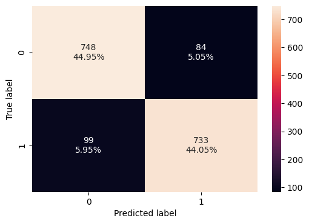

```python
confusion_matrix_sklearn(dt_under_tuned, X_train_un, y_train_un)
```

```python
dt_under_val = model_performance_classification_sklearn(
    dt_under_tuned, X_val, y_val
)
print("Validation Performance:")
dt_under_val
```

```
Validation Performance:
```

|  | Accuracy | Recall | Precision | F1 |
| --- | --- | --- | --- | --- |
| 0 | 0.872 | 0.874 | 0.287 | 0.432 |

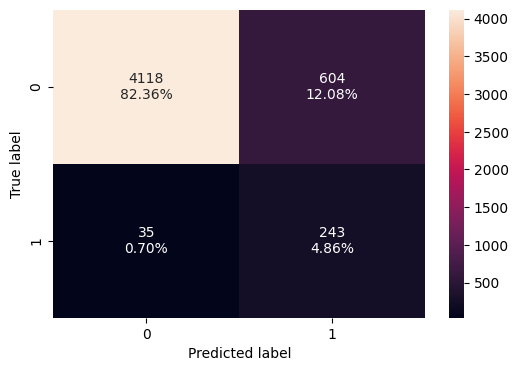

```python
confusion_matrix_sklearn(dt_under_tuned, X_val, y_val)
```

**HYPERTUNING XG BOOSTING USING OVERSAMPLED DATA**

```python
%%time

Model = XGBClassifier(random_state=1,eval_metric='logloss')

param_grid={'n_estimators':[150,200,250],'scale_pos_weight':[5,10], 'learning_rate':[0.1,0.2], 'gamma':[0,3,5], 'subsample':[0.8,0.9]}

randomized_cv = RandomizedSearchCV(estimator=Model, param_distributions=param_grid, n_iter=50, n_jobs = -1, scoring=scorer, cv=5, random_state=1)

randomized_cv.fit(X_train_over, y_train_over)

print("Best parameters are {} with CV score={}:" .format(randomized_cv.best_params_,randomized_cv.best_score_))
```

```
Best parameters are {'subsample': 0.9, 'scale_pos_weight': 10, 'n_estimators': 150, 'learning_rate': 0.1, 'gamma': 0} with CV score=0.9960475154078072:
CPU times: user 24.3 s, sys: 8.22 s, total: 32.5 s
Wall time: 12min 17s
```

```python
xgb_tuned = XGBClassifier(
    random_state=1,
    eval_metric="logloss",
    subsample=0.2,
    scale_pos_weight=5,
    n_estimators=30,
    learning_rate=1,
    gamma=3,
)

xgb_tuned.fit(X_train_over, y_train_over)
```

```
XGBClassifier(base_score=None, booster=None, callbacks=None,
              colsample_bylevel=None, colsample_bynode=None,
              colsample_bytree=None, device=None, early_stopping_rounds=None,
              enable_categorical=False, eval_metric='logloss',
              feature_types=None, gamma=3, grow_policy=None,
              importance_type=None, interaction_constraints=None,
              learning_rate=1, max_bin=None, max_cat_threshold=None,
              max_cat_to_onehot=None, max_delta_step=None, max_depth=None,
              max_leaves=None, min_child_weight=None, missing=nan,
              monotone_constraints=None, multi_strategy=None, n_estimators=30,
              n_jobs=None, num_parallel_tree=None, random_state=1, ...)
```

```python
xgb_train = model_performance_classification_sklearn(
   xgb_tuned, X_train_over, y_train_over
)
xgb_train
```

|  | Accuracy | Recall | Precision | F1 |
| --- | --- | --- | --- | --- |
| 0 | 0.941 | 0.972 | 0.914 | 0.942 |

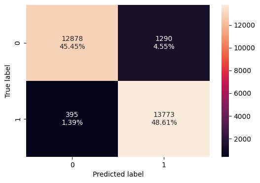

```python
confusion_matrix_sklearn(xgb_tuned, X_train_over, y_train_over)
```

```python
xgb_val = model_performance_classification_sklearn(xgb_tuned, X_val, y_val)
xgb_val
```

|  | Accuracy | Recall | Precision | F1 |
| --- | --- | --- | --- | --- |
| 0 | 0.893 | 0.863 | 0.325 | 0.472 |

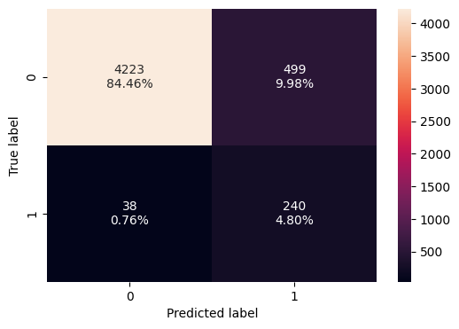

```python
confusion_matrix_sklearn(xgb_tuned, X_val, y_val)
```

**HYPERTUNING GRADIENT BOOSTING USING UNDERSAMPLED DATA**

```python
%%time

Model = GradientBoostingClassifier(random_state=1)

param_grid={"n_estimators": np.arange(100,150,25), "learning_rate": [0.2, 0.05, 1], "subsample":[0.5,0.7], "max_features":[0.5,0.7]}

randomized_cv = RandomizedSearchCV(estimator=Model, param_distributions=param_grid, scoring=scorer, n_iter=50, n_jobs = -1, cv=5, random_state=1)

randomized_cv.fit(X_train_un, y_train_un)

print("Best parameters are {} with CV score={}:" .format(randomized_cv.best_params_,randomized_cv.best_score_))
```

```
Best parameters are {'subsample': 0.5, 'n_estimators': 100, 'max_features': 0.7, 'learning_rate': 0.2} with CV score=0.9014212538777866:
CPU times: user 2.14 s, sys: 210 ms, total: 2.35 s
Wall time: 1min 31s
```

```python
gbm_tuned = GradientBoostingClassifier(
    max_features=0.7,
    random_state=1,
    learning_rate=1,
    n_estimators=75,
    subsample=0.3
)

gbm_tuned.fit(X_train_un, y_train_un)
```

```
GradientBoostingClassifier(learning_rate=1, max_features=0.7, n_estimators=75,
                           random_state=1, subsample=0.3)
```

```python
gbm_train= model_performance_classification_sklearn(
    gbm_tuned, X_train_un, y_train_un
)
print("Training Performance:")
gbm_train
```

```
Training Performance:
```

|  | Accuracy | Recall | Precision | F1 |
| --- | --- | --- | --- | --- |
| 0 | 0.883 | 0.906 | 0.866 | 0.885 |

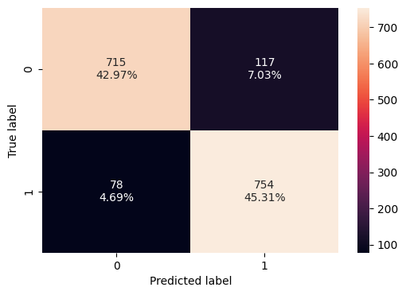

```python
confusion_matrix_sklearn(gbm_tuned, X_train_un, y_train_un)
```

```python
gbm_val = model_performance_classification_sklearn(gbm_tuned, X_val, y_val)
print("Validation Performance:")
gbm_val
```

```
Validation Performance:
```

|  | Accuracy | Recall | Precision | F1 |
| --- | --- | --- | --- | --- |
| 0 | 0.775 | 0.845 | 0.178 | 0.294 |

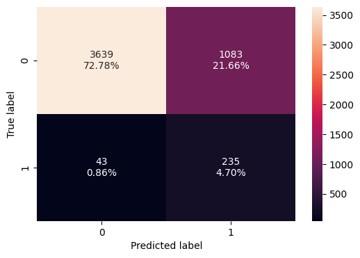

```python
confusion_matrix_sklearn(gbm_tuned, X_val, y_val)
```

**HYPERTUNING XG BOOST USING UNDERSAMPLED DATA**

```python
%%time

Model = XGBClassifier(random_state=1,eval_metric='logloss')

param_grid={'n_estimators':[150,200,250],'scale_pos_weight':[5,10], 'learning_rate':[0.1,0.2], 'gamma':[0,3,5], 'subsample':[0.8,0.9]}

randomized_cv = RandomizedSearchCV(estimator=Model, param_distributions=param_grid, n_iter=50, n_jobs = -1, scoring=scorer, cv=5, random_state=1)

randomized_cv.fit(X_train_un, y_train_un)

print("Best parameters are {} with CV score={}:" .format(randomized_cv.best_params_,randomized_cv.best_score_))
```

```
Best parameters are {'subsample': 0.9, 'scale_pos_weight': 10, 'n_estimators': 200, 'learning_rate': 0.1, 'gamma': 5} with CV score=0.9290599523843879:
CPU times: user 3.42 s, sys: 269 ms, total: 3.69 s
Wall time: 2min 16s
```

```python
xgb_under_tuned = XGBClassifier(
    random_state=1,
    eval_metric="logloss",
    subsample=0.2,
    scale_pos_weight=5,
    n_estimators=30,
    learning_rate=1,
    gamma=3,
)

xgb_under_tuned.fit(X_train_un, y_train_un)
```

```
XGBClassifier(base_score=None, booster=None, callbacks=None,
              colsample_bylevel=None, colsample_bynode=None,
              colsample_bytree=None, device=None, early_stopping_rounds=None,
              enable_categorical=False, eval_metric='logloss',
              feature_types=None, gamma=3, grow_policy=None,
              importance_type=None, interaction_constraints=None,
              learning_rate=1, max_bin=None, max_cat_threshold=None,
              max_cat_to_onehot=None, max_delta_step=None, max_depth=None,
              max_leaves=None, min_child_weight=None, missing=nan,
              monotone_constraints=None, multi_strategy=None, n_estimators=30,
              n_jobs=None, num_parallel_tree=None, random_state=1, ...)
```

```python
xgb_under_train = model_performance_classification_sklearn(
   xgb_under_tuned, X_train_un, y_train_un
)
print("Training Performance:")
xgb_under_train
```

```
Training Performance:
```

|  | Accuracy | Recall | Precision | F1 |
| --- | --- | --- | --- | --- |
| 0 | 0.821 | 0.887 | 0.783 | 0.832 |

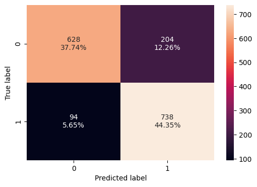

```python
confusion_matrix_sklearn(xgb_under_tuned, X_train_un, y_train_un)
```

```python
xgb_under_val = model_performance_classification_sklearn(
   xgb_under_tuned, X_val, y_val
)
print("Validation Performance:")
xgb_under_val
```

```
Validation Performance:
```

|  | Accuracy | Recall | Precision | F1 |
| --- | --- | --- | --- | --- |
| 0 | 0.741 | 0.849 | 0.159 | 0.267 |

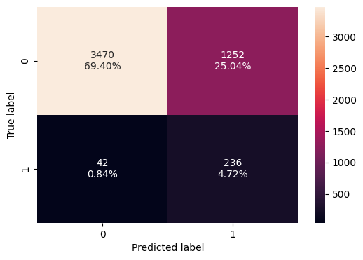

```python
confusion_matrix_sklearn(xgb_under_tuned, X_val, y_val)
```

**HYPERTUNING RANDOM FOREST USING UNDERSAMPLED DATA**

```python
%%time

Model = RandomForestClassifier(random_state=1)

param_grid = {
    "n_estimators": [200,250,300],
    "min_samples_leaf": np.arange(1, 4),
    "max_features": [np.arange(0.3, 0.6, 0.1),'sqrt'],
    "max_samples": np.arange(0.4, 0.7, 0.1)}

randomized_cv = RandomizedSearchCV(estimator=Model, param_distributions=param_grid, n_iter=50, n_jobs = -1, scoring=scorer, cv=5, random_state=1)


randomized_cv.fit(X_train_un, y_train_un)

print("Best parameters are {} with CV score={}:" .format(randomized_cv.best_params_,randomized_cv.best_score_))
```

```
Best parameters are {'n_estimators': 300, 'min_samples_leaf': 2, 'max_samples': 0.5, 'max_features': 'sqrt'} with CV score=0.8990116153235697:
CPU times: user 3.58 s, sys: 207 ms, total: 3.78 s
Wall time: 2min 3s
```

```python
rf_under_tuned = RandomForestClassifier(
    max_features=0.6,
    random_state=1,
    max_samples=0.7,
    n_estimators=75,
    min_samples_leaf=4
)

rf_under_tuned.fit(X_train_un,y_train_un)
```

```
RandomForestClassifier(max_features=0.6, max_samples=0.7, min_samples_leaf=4,
                       n_estimators=75, random_state=1)
```

```python
rf_under_train = model_performance_classification_sklearn(rf_under_tuned, X_train_un, y_train_un)
print("Training Performance:")
rf_under_train
```

```
Training Performance:
```

|  | Accuracy | Recall | Precision | F1 |
| --- | --- | --- | --- | --- |
| 0 | 0.957 | 0.927 | 0.986 | 0.955 |

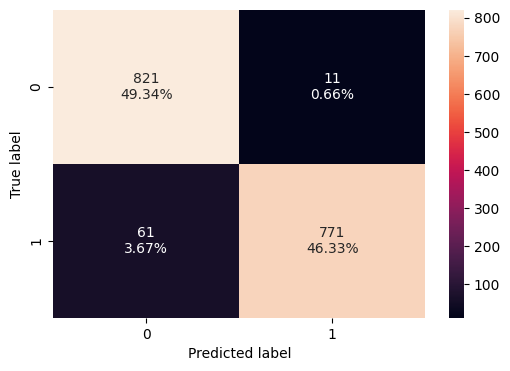

```python
confusion_matrix_sklearn(rf_under_tuned, X_train_un, y_train_un)
```

```python
rf_under_val = model_performance_classification_sklearn(rf_under_tuned, X_train_over, y_train_over)
print("Validation Performance:")
rf_under_val
```

[output not shown]

|  | Accuracy | Recall | Precision | F1 |
| --- | --- | --- | --- | --- |
| 0 | 0.936 | 0.926 | 0.944 | 0.935 |

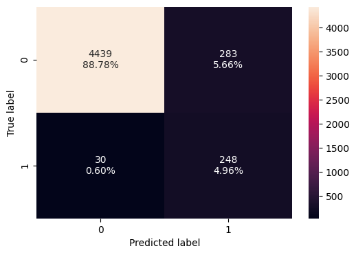

```python
confusion_matrix_sklearn(rf_under_tuned, X_val, y_val)
```

## Model performance comparison and choosing the final model

**TRAINING PERFORMANCE COMPARISON**

```python
models_train_comp_df = pd.concat(
    [
     xgb_train.T,
     gbm_train.T,
     xgb_under_train.T,
     rf_under_train.T,
    ],
    axis=1,
)
models_train_comp_df.columns = [
    "XGBoost tuned using oversampled data",
    "Gradient Boosting tuned using undersampled data",
    "XGBoost tuned using underrsampled data",
    "Random Forest tuned using undersampled data",
]
print("Training performance comparison:")
models_train_comp_df
```

```
Training performance comparison:
```

|  | XGBoost tuned using oversampled data | Gradient Boosting tuned using undersampled data | XGBoost tuned using underrsampled data | Random Forest tuned using undersampled data |
| --- | --- | --- | --- | --- |
| Accuracy | 0.941 | 0.883 | 0.821 | 0.957 |
| Recall | 0.972 | 0.906 | 0.887 | 0.927 |
| Precision | 0.914 | 0.866 | 0.783 | 0.986 |
| F1 | 0.942 | 0.885 | 0.832 | 0.955 |

**VALIDATION PERFORMANCE COMPARISON**

```python
models_val_comp_df = pd.concat(
    [
     xgb_val.T,
     gbm_val.T,
     xgb_under_val.T,
     rf_under_val.T,
    ],
    axis=1,
)
models_val_comp_df.columns = [
    "XGBoost tuned using oversampled data",
    "Gradient Boosting tuned using undersampled data",
    "XGBoost tuned using underrsampled data",
    "Random Forest tuned using undersampled data",
]
print("Validation performance comparison:")
models_val_comp_df
```

```
Validation performance comparison:
```

|  | XGBoost tuned using oversampled data | Gradient Boosting tuned using undersampled data | XGBoost tuned using underrsampled data | Random Forest tuned using undersampled data |
| --- | --- | --- | --- | --- |
| Accuracy | 0.893 | 0.775 | 0.741 | 0.936 |
| Recall | 0.863 | 0.845 | 0.849 | 0.926 |
| Precision | 0.325 | 0.178 | 0.159 | 0.944 |
| F1 | 0.472 | 0.294 | 0.267 | 0.935 |

### Test set final performance

```python
model_test = model_performance_classification_sklearn(rf_under_tuned, X_test, y_test)
print("Test performance:")
model_test
```

```
Test performance:
```

|  | Accuracy | Recall | Precision | F1 |
| --- | --- | --- | --- | --- |
| 0 | 0.939 | 0.872 | 0.478 | 0.617 |

**FEATURE IMPORTANCES**

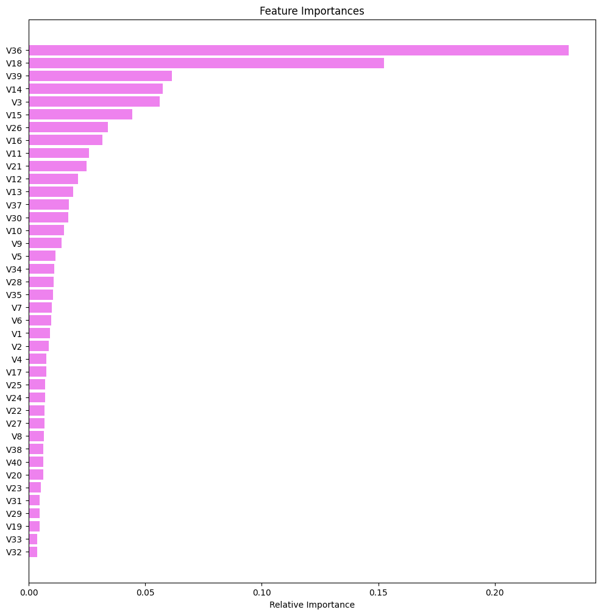

```python
feature_names = X.columns
importances = rf_under_tuned.feature_importances_
indices = np.argsort(importances)

plt.figure(figsize=(12, 12))
plt.title("Feature Importances")
plt.barh(range(len(indices)), importances[indices], color="violet", align="center")
plt.yticks(range(len(indices)), [feature_names[i] for i in indices])
plt.xlabel("Relative Importance")
plt.show()
```

## Pipelines to build the final model

```python
Pipeline_model = Pipeline(
    steps=[
        (
           "Random Forest",
            RandomForestClassifier(
                max_features=0.6,
                random_state=1,
                max_samples=0.7,
                n_estimators=75,
                min_samples_leaf=4
        ),
        ),
    ]
)

Pipeline_model.fit(X_train, y_train)
```

```
Pipeline(steps=[('Random Forest',
                 RandomForestClassifier(max_features=0.6, max_samples=0.7,
                                        min_samples_leaf=4, n_estimators=75,
                                        random_state=1))])
```

```python
X1 = data_train.drop(columns="Target")
Y1 = data_train["Target"]

X_test1 = df_test.drop(columns="Target")
y_test1 = df_test["Target"]
```

```python
imputer = SimpleImputer(strategy="median")
X1 = imputer.fit_transform(X1)
```

```python
rus = RandomUnderSampler(random_state=1, sampling_strategy=1)
X_train_un, y_train_un = rus.fit_resample(X_train, y_train)
```

```python
Pipeline_model.fit(X_train,y_train)
```

```
Pipeline(steps=[('Random Forest',
                 RandomForestClassifier(max_features=0.6, max_samples=0.7,
                                        min_samples_leaf=4, n_estimators=75,
                                        random_state=1))])
```

```python
Pipeline_model_test = model_performance_classification_sklearn(rf_under_tuned, X_test, y_test)
print("Test performance:")
Pipeline_model_test
```

```
Test performance:
```

|  | Accuracy | Recall | Precision | F1 |
| --- | --- | --- | --- | --- |
| 0 | 0.939 | 0.872 | 0.478 | 0.617 |

# Business Insights and Conclusions

1. Random Forest Classification model built seemed to model performing the best in identifying failures.
2. According to the analysis performed on the models, The Random Forest model that was built was about 94% accurate, as compared to the performance of the other models.
3. ReneWind can implement several strategies for cutting costs to repair the generators as repairing the model seems to be more expensive than replacing the model.
4. The wind turbines can be built with longer blades and taller towers by the company so as to increase efficiency and generate more wind energy.
5. The company can increase the number of inspections on the generators to ensure accurate and proper predictions by the model as the cost of inspections is less than the cost of repairing the model (if and when the model fails to predict accurately)